# Creating a Scatterplot with Texture

Tejas Guha

January 21, 2021

## Importing Local Libraries

```r
library(scatterHatch)
```

## Preparing the Data

The data that will be used to showcase the function is [a tissue-CyCIF PDAC dataset from Lin et al](http://spatial.rc.fas.harvard.edu/spatialgiotto/giotto.cycif.html). The preprocessing begins by adding manual annotations for each cell’s location in the tissue sample.

```r
pdacData = scatterHatch::pdacData
pdacData$cellID = paste0('cell_', 1:nrow(pdacData))
pdacData$Yt <- -pdacData$Yt
pancreas_frames = c(1:6, 27:31, 15:19, 40:44)
PDAC_frames = c(23:26, 35:37, 51:52, 64:65, 77)
small_intestines_frames = c(49:50, 63, 75:76, 88:89, 100:103, 112:116, 125:129, 137:140)
annotateLocation <- function(frame){
  if (frame %in% pancreas_frames){return("Pancreas")}
  if (frame %in% PDAC_frames){return("PDAC")}
  if (frame %in% small_intestines_frames){return("Small Intestine")}
  return("Other")
}
pdacData$location = sapply(pdacData$frame, annotateLocation)

head(pdacData[, c('Xt', 'Yt', 'location', 'frame')])
```

```
#>         Xt        Yt location frame
#> 1 1342.878  -801.154 Pancreas     1
#> 2 5688.494 -1391.393 Pancreas     4
#> 3 6295.826 -1393.807 Pancreas     4
#> 4 5344.257 -1391.650 Pancreas     4
#> 5 5640.034 -1391.416 Pancreas     4
#> 6 5923.357 -1390.776 Pancreas     4
```

## Creating a Basic ScatterHatch Plot

`scatterHatch()` must have a data frame passed to it, along with three strings denoting the columns with the x/y coordinates and a factor variable of each point being plotted. The factor variable identifies the group each point is a part of. `scatterHatch()` returns a ggplot2 object with three layers; the points, the line segments (the hatching), and an invisible custom geom to render the legend icons.

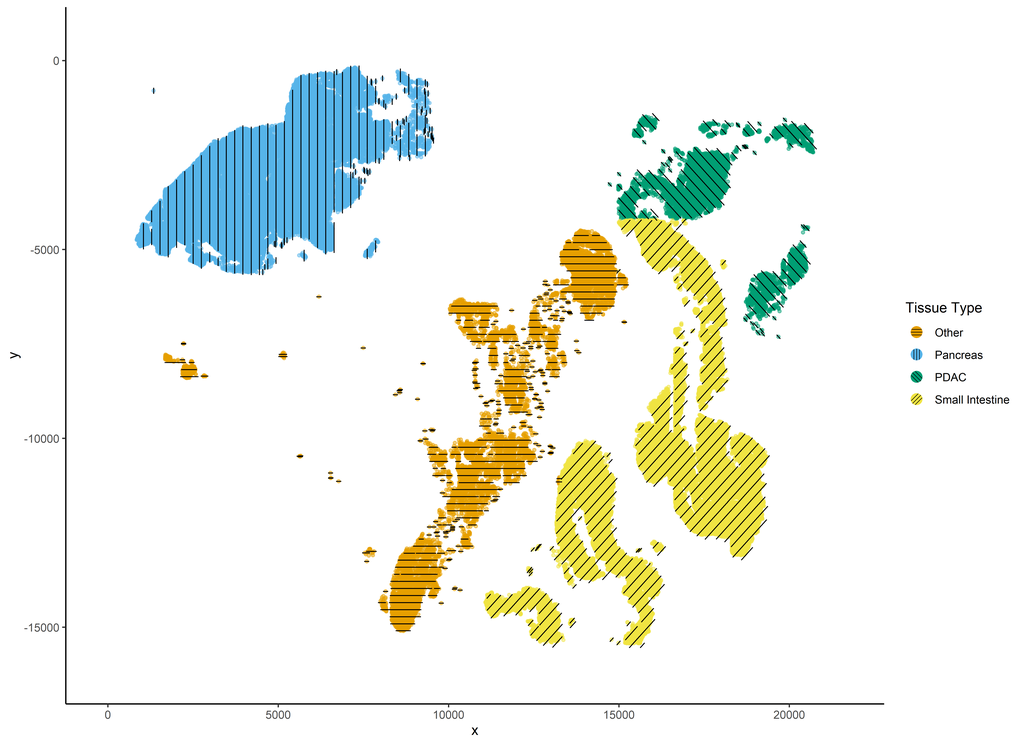

```r
plt <- scatterHatch(data = pdacData, x = "Xt", y = "Yt", factor = "location", legendTitle = "Tissue Type")
plot(plt)
```

## Creating ScatterHatch Plot with Many Groups

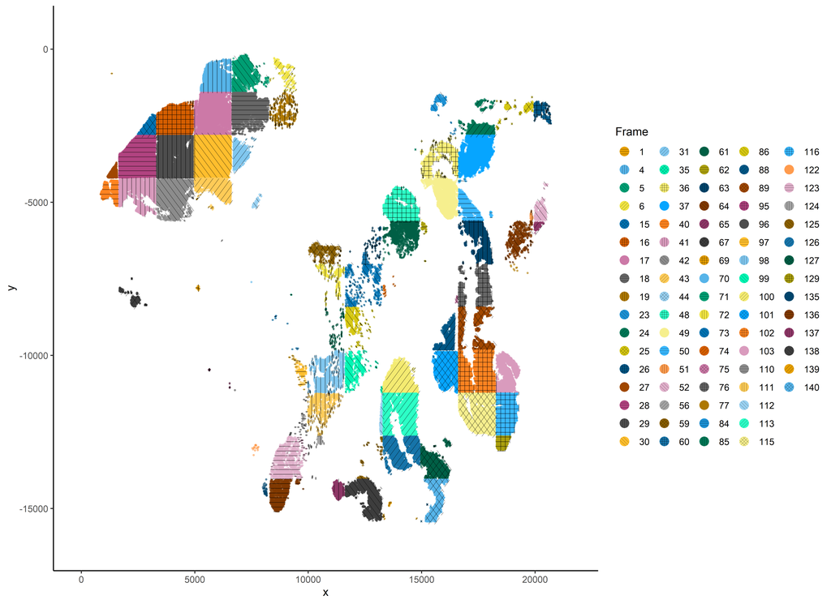

```r
plt <- scatterHatch(data = pdacData, x = "Xt", y = "Yt", factor = "frame", pointSize = 0.5,
    legendTitle = "Frame")
plot(plt)
```

## Customizing ScatterHatch Plot

### Changing the Order of Pattern Assignment

Controlling the aesthetics of each pattern is done by passing a list to the `patternList` argument. Each element of the list should contain a list that denotes the desired aesthetics for each pattern. Every element of `patternList` must have a named element called “pattern” that contains the unique pattern type for which the aesthetics are being changed. If patternList is passed, then the length of patternList must be equal to the number of groups being plotted.

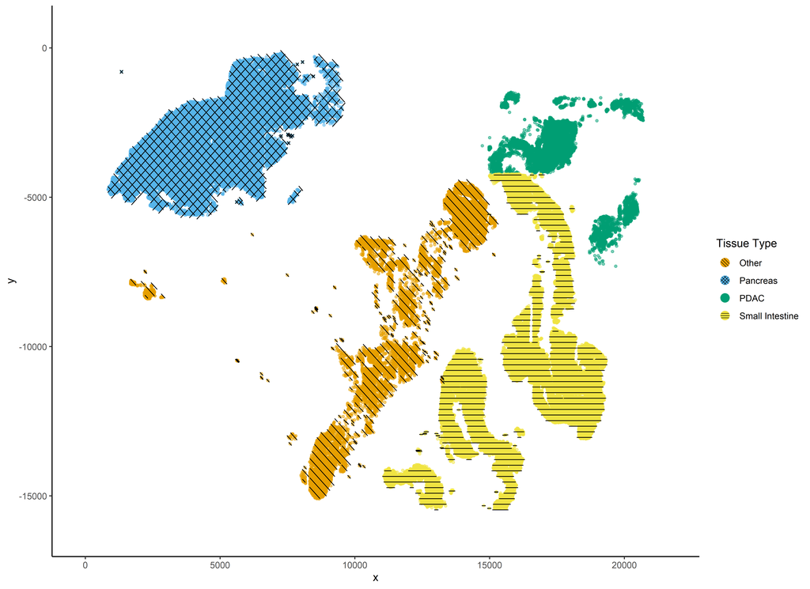

```r
patternList = list(list(pattern = "/"), list(pattern = "x"), list(pattern = ""),
    list(pattern = "-"))
plt <- scatterHatch(data = pdacData, x = "Xt", y = "Yt", factor = "location", legendTitle = "Tissue Type",
    patternList = patternList)
plot(plt)
```

### Changing the Aesthetics of each Pattern

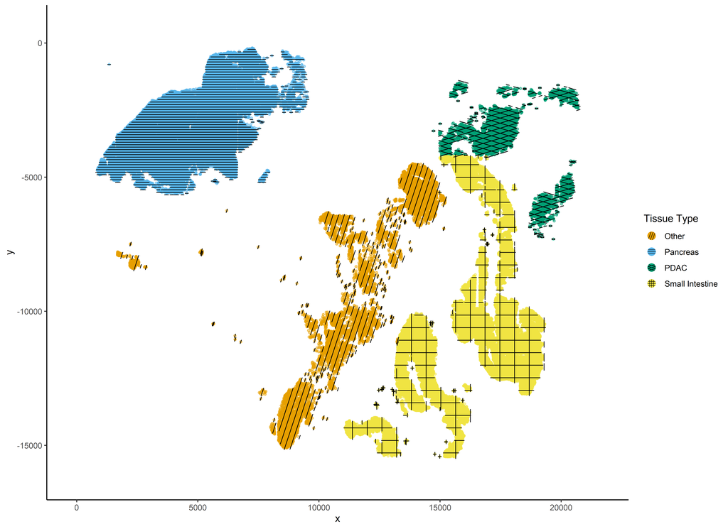

```r
patternList = list(list(pattern = "/", angle = 70), list(pattern = "-", density = 1/2),
    list(pattern = "x", angle = c(15, 165)), list(pattern = "+", density = 1/10))
plt <- scatterHatch(data = pdacData, x = "Xt", y = "Yt", factor = "location", legendTitle = "Tissue Type",
    patternList = patternList)
plot(plt)
```

## scatterHatch() Arguments Explained

[output not shown]

## Pattern Aesthetics Arguments

These pattern aesthetics are passed into a list in the patternList argument of `scatterHatch()`.

[output not shown]